# Tendencias temporales de las personas que declararon cambiar de residencia como medida de protección contra la delincuencia

Encuesta Nacional de Victimización y Percepción sobre la Pública (ENVIPE)

Diana Villasana Ocampo

La Encuesta Nacional de Victimización y Percepción sobre Seguridad Pública [(`ENVIPE`)](https://www.inegi.org.mx/programas/envipe/2024/) es un instrumento estadístico diseñado por el Instituto Nacional de Estadística y Geografía [(`INEGI`)](https://www.inegi.org.mx/default.html) en México. Su objetivo principal es generar información sobre la magnitud y características de la victimización en el país, así como evaluar la percepción de los ciudadanos sobre la seguridad pública y el desempeño de las instituciones encargadas de la justicia y la seguridad.

La importancia de la ENVIPE:

- Planeación y diseño de políticas públicas: Proporciona datos fundamentales para que los gobiernos federal, estatal y municipal diseñen estrategias de prevención del delito.
- Evaluación del sistema de justicia: Permite identificar áreas de oportunidad en las instituciones encargadas de la seguridad pública y la justicia.
- Información para académicos y sociedad civil: Los datos son utilizados en investigaciones y análisis independientes que buscan mejorar el entendimiento del fenómeno delictivo en México.

## Características

El propósito de la ENVIPE es proporcionar datos representativos y confiables para entender:

- **La prevalencia delictiva**: Cuántas personas han sido víctimas de delitos en el último año.
- **El impacto de la delincuencia**: Analizar las consecuencias económicas, sociales y psicológicas de los delitos.
- **La percepción de seguridad**: Evaluar cómo las personas perciben su entorno en términos de seguridad, a nivel local, estatal y nacional.
- **La confianza en las autoridades**: Medir la opinión pública sobre las instituciones de seguridad pública, justicia y procuración de justicia.
- **La cifra negra:** Identificar los delitos que no son denunciados o que, aunque son denunciados, no se investigan, revelando el nivel de subregistro.

## Tipo de información

La encuesta recoge información sobre:

- **Características sociodemográficas de los hogares y las personas**: Edad, sexo, nivel educativo, ocupación, entre otros.
- **Victimización:**
  - Delitos más comunes (robos, fraudes, extorsiones, etc.).
  - Lugares y momentos en que ocurren.
  - Medios utilizados por los delincuentes.
  - Perfiles de las víctimas.
- **Costos del delito**: Incluye pérdidas materiales, costos emocionales y gastos relacionados con medidas preventivas.
- **Percepción de inseguridad:**
  - Opinión sobre la seguridad en espacios públicos como calles, parques, mercados y transporte público.
  - Sensación de inseguridad a nivel estatal y nacional.
- **Confianza y desempeño de las instituciones**:
  - Opinión sobre la policía, el Ministerio Público, el ejército, la Guardia Nacional, entre otros.
  - Niveles de denuncia y razones para no denunciar (desconfianza, trámites complicados, etc.).
- **Medidas de autoprotección**: Acciones que los ciudadanos toman para evitar ser víctimas de delitos.

## Diseño muestral

La ENVIPE utiliza un diseño probabilístico, estratificado, por conglomerados y en múltiples etapas. Sus características son:

**Población objetivo**

La encuesta está dirigida a la población de 18 años cumplidos o más, que reside permanentemente en viviendas particulares dentro del territorio nacional.

**Cobertura geográfica**

La encuesta está diseñada para dar resultados a los siguientes niveles de desagregación:

- Nacional.
  - Urbano.
  - Rural.
- Entidad federativa.
- 34 áreas urbanas de interés, con la Ciudad de México dividida en cuatro regiones geográficas (Norte, sur, oriente y poniente).

### Marco muestral

El diseño de la muestra para la ENVIPE se caracteriza por ser **probabilístico**; a la vez, el diseño es **trietápico**, **estratificado** y por **conglomerados**, donde la unidad última de selección es la vivienda y las unidades de observación son los hogares y las personas de 18 años cumplidos o más.

#### Unidad Primaria de Muestreo (`UPM`)

La división política del país y la conformación de localidades diferenciadas por su tamaño, forman de manera natural una estratificación geográfica. En cada entidad federativa se distinguen tres ámbitos, divididos a su vez en zonas, como se indica en el siguiente cuadro:

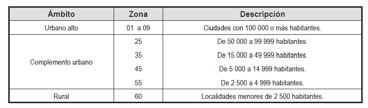

Fuente: INEGI. Encuesta Nacional de Victimización y Percepción sobre Seguridad Pública.

#### Estratificación

Se formaron cuatro estratos sociodemográficos en los que se agruparon todas las UPM del país, esta estratificación considera las características sociodemográficas de los habitantes de las viviendas, así como las características físicas y el equipamiento de las mismas, expresadas por medio de 34 indicadores* construidos con información del Censo de Población y Vivienda 2010, para lo cual se emplearon métodos estadísticos multivariados.

Indicadores empleados en la estratificación de la muestra maestra

ENVIPE

| Mnemónico | Descripción |
| --- | --- |
| Población |  |
| PPSSNOSP | Que tiene derecho a recibir servicios médicos en alguna institución de salud pública o privada excepto seguro popular. |
| PPDER_SS | Derechohabiente a servicios de salud. |
| PDP3A14A | De 3 a 14 años de edad que asiste a la escuela. |
| PDP15A24A | De 15 a 24 años de edad que asiste a la escuela. |
| PDP8A14ALF | De 8 a 14 años de edad que saben leer o escribir. |
| PDP15YM_SE | De 15 años o más de edad que aprobaron algún grado de escolaridad diferente al nivel preescolar. |
| PP15PRI_CO | De 15 años o más de edad que tienen como máxima escolaridad 6 grados aprobados en primaria. |
| PP15SEC_CO | De 15 años o más de edad que tienen como máxima escolaridad 3 grados aprobados en secundaria. |
| PGDO_ESC | Grado promedio de escolaridad. |
| PPEA | De 12 años y más que trabajaron; tenían trabajo pero no trabajaron o; buscaron trabajo en la semana de referencia. |
| PPEA_F | Femenina de 12 años y más que trabajaron; tenían trabajo pero no trabajaron o; buscaron trabajo en la semana de referencia. |
| PTASAOCUPA | Tasa de ocupación. |
| TOCU12A17 | No ocupada de 12 a 17 años de edad entre la población de 12 a 17 años de edad. |
| PPOMAYED | Ocupada de 18 y más años de edad entre la población ocupada. |
| Viviendas Particulares Habitadas |  |
| PVIVSINH | Que no tienen hacinamiento. |
| PVPH_PISDT | Que tienen piso de cemento o firme, madera, mosaico u otro material. |
| PVPH2YMASD | Que usan para dormir entre 2 y 25 cuartos. |
| PVPH_2MASC | Que tienen más de un cuarto. |
| PVPH3YMASC | Que tienen entre 3 y 25 cuartos. |
| PVPH_C_ELE | Que disponen de luz eléctrica. |
| PVPHAGUADV | Que tienen disponibilidad de agua entubada dentro de la vivienda, o fuera de la vivienda pero dentro del terreno. |
| PVPH_EXCSA | Que tienen excusado, retrete, sanitario, letrina u hoyo negro. |
| PVPHDRENAJ | Que tienen drenaje conectado a la red pública, fosa séptica, barranca, grieta, rio, lago o mar. |
| PVDRERED | Que disponen de drenaje conectado a la red pública. |
| PVEXCAGU | Que disponen de excusado con descarga directa de agua. |
| PVPH_CSERV | Que disponen de luz eléctrica, agua entubada dentro o fuera de la vivienda, pero dentro del terreno, así como drenaje. |
| PSIN_HASIN | Que no se encuentran en situación de hacinamiento a nivel manzana. |
| Viviendas Particulares Habitadas que disponen de |  |
| PVPH_TV | Televisor. |
| PVPH_AUTOM | Automóvil o camioneta. |
| PVPH_CEL | Teléfono celular. |
| PVCELFIJ | Teléfono celular y teléfono fijo. |
| PV4ELEC | Radio, televisor, refrigerador y lavadora. |
| PVRADTEL | Radio y televisor. |
| PVPHCBIEN | Todos los bienes. |

Fuente: INEGI. Encuesta Nacional de Victimización y Percepción sobre Seguridad Pública.

## Bases de datos

> `AP4_11_10 4.11` Durante 202x, para protegerse de la delincuencia, ¿en este hogar se realizó algún tipo de medida como… cambiarse de vivienda o lugar de residencia?

## Personas

AP4_11_10 4.11 Durante 202x, para protegerse de la delincuencia, ¿en este hogar se realizó algún tipo de medida como… cambiarse de vivienda o lugar de residencia?

```r
Personas <- read_xlsx(paste0(here::here(), "/Bases/MC_ENVIPE 2011 - 2024.xlsx"),
                      sheet = "Promedios",
                      range = "C5:L19",
                      col_names = TRUE)
```

Durante 2023, para protegerse de la delincuencia, ¿en este hogar se realizó algún tipo de medida como… cambiarse de vivienda o lugar de residencia?

Total de personas que cambiaron de vivienda o lugar de residencia

| Año | **Estimación** | CI (5%) | CS (95%) | Promedio (2 años) | Promedio (3 años) | Promedio (4 años) | Variación (2 años) | Variación (3 años) | Variación (4 años) |
| --- | --- | --- | --- | --- | --- | --- | --- | --- | --- |
| 2011 | 396 394 | 365 889 | 426 899 | NA | NA | NA | NA | NA | NA |
| 2012 | 324 716 | 299 804 | 349 628 | 360 555 | NA | NA | −18.0825 | NA | NA |
| 2013 | 419 021 | 386 139 | 451 903 | 371 869 | 380 044 | NA | 29.0423 | 5.7082 | NA |
| 2014 | 390 209 | 360 373 | 420 045 | 404 615 | 377 982 | 382 585 | −6.8760 | 20.1693 | −1.5603 |
| 2015 | 383 245 | 356 252 | 410 238 | 386 727 | 397 492 | 379 298 | −1.7847 | −8.5380 | 18.0247 |
| 2016 | 256 615 | 234 827 | 278 403 | 319 930 | 343 356 | 362 273 | −33.0415 | −34.2365 | −38.7584 |
| 2017 | 326 626 | 302 625 | 350 627 | 291 621 | 322 162 | 339 174 | 27.2825 | −14.7736 | −16.2946 |
| 2018 | 315 330 | 291 878 | 338 782 | 320 978 | 299 524 | 320 454 | −3.4584 | 22.8806 | −17.7210 |
| 2019 | 474 476 | 439 286 | 509 666 | 394 903 | 372 144 | 343 262 | 50.4697 | 45.2658 | 84.8980 |
| 2020 | 371 024 | 342 403 | 399 645 | 422 750 | 386 943 | 371 864 | −21.8034 | 17.6621 | 13.5929 |
| 2021 | 281 373 | 257 906 | 304 840 | 326 199 | 375 624 | 360 551 | −24.1631 | −40.6982 | −10.7687 |
| 2022 | 249 547 | 228 000 | 271 094 | 265 460 | 300 648 | 344 105 | −11.3110 | −32.7410 | −47.4058 |
| 2023 | 219 083 | 200 316 | 237 850 | 234 315 | 250 001 | 280 257 | −12.2077 | −22.1379 | −40.9518 |
| 2024 | 320 726 | 292 562 | 348 890 | 269 905 | 263 119 | 267 682 | 46.3947 | 28.5233 | 13.9861 |

Fuente: INEGI. Encuesta Nacional de Victimización y Percepción sobre Seguridad Pública, 2010 - 2023.